# Advanced Bioinformatics 2023 assessment

m2210296

2023-04-19

# General R/Rstudio assessment (33 pts)

## Question 3.1

```r
sum(5:55)
```

```
## [1] 1530
```

## Question 3.2

```r
sumfun <- function(n) {sum(5:n)}

result1 <- sumfun(10)
result2 <- sumfun(20)
result3 <- sumfun(100)

# Print the results
cat("The sum of integers between 5 and 10 is", result1, "\n")
```

```
## The sum of integers between 5 and 10 is 45
```

```r
cat("The sum of integers between 5 and 20 is", result2, "\n")
```

```
## The sum of integers between 5 and 20 is 200
```

```r
cat("The sum of integers between 5 and 100 is", result3, "\n")
```

```
## The sum of integers between 5 and 100 is 5040
```

## Question 3.3

```r
# The first two values must be manually stated
fb <- c(1,1)
# now loop over the next values
for (i in 3:12) {
  fb1 <- fb[i-1]+fb[i-2]
  fb <- c(fb,fb1)
}
cat("The Fibonacci series is", fb)
```

```
## The Fibonacci series is 1 1 2 3 5 8 13 21 34 55 89 144
```

## Question 3.4

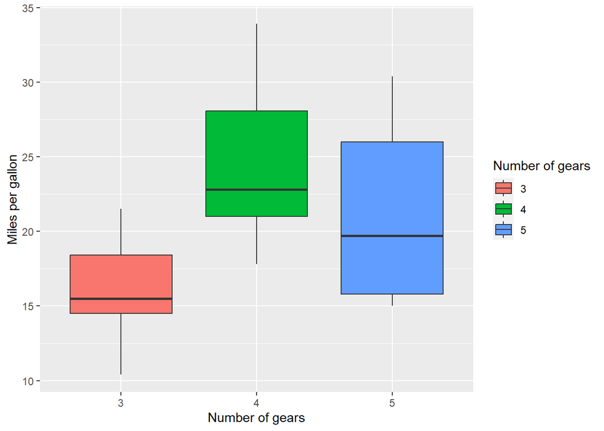

```r
library(ggplot2)
ggplot(mtcars, aes(x = factor(gear), y = mpg, fill = factor(gear))) +geom_boxplot() +  labs(x = "Number of gears", y = "Miles per gallon", fill = "Number of gears")
```

## Question 3.5

```r
mdl <- lm(dist ~ speed, data = cars)
summary(mdl)
```

```
##
## Call:
## lm(formula = dist ~ speed, data = cars)
##
## Residuals:
##     Min      1Q  Median      3Q     Max
## -29.069  -9.525  -2.272   9.215  43.201
##
## Coefficients:
##             Estimate Std. Error t value Pr(>|t|)
## (Intercept) -17.5791     6.7584  -2.601   0.0123 *
## speed         3.9324     0.4155   9.464 1.49e-12 ***
## ---
## Signif. codes:  0 '***' 0.001 '**' 0.01 '*' 0.05 '.' 0.1 ' ' 1
##
## Residual standard error: 15.38 on 48 degrees of freedom
## Multiple R-squared:  0.6511, Adjusted R-squared:  0.6438
## F-statistic: 89.57 on 1 and 48 DF,  p-value: 1.49e-12
```

The speed is given in mph and the stopping distance is given in feet. The intercept is -17.579 feet and the stopping distance increases by 3.932 feet for each 1 mph increase in speed (the fitted slope). The standard errors are 6.758 for the intercept and 0.416 for speed. The intercept is significant at the 0.05 level and the speed variable is significant at the 0.001 level. Note that very low speeds result in a negative predicted stopping distance, which is an artefact of the regression and predicted values should only be used above this threshold.

## Question 3.6

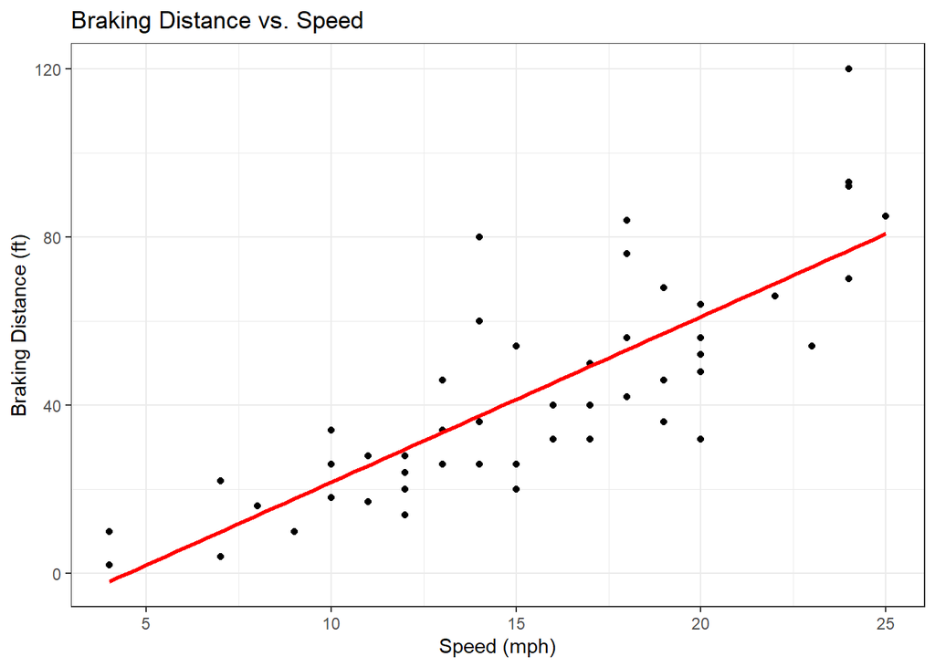

```r
ggplot(cars, aes(x = speed, y = dist)) +
  geom_point() +
  geom_smooth(method = "lm", se = FALSE, color = "red") +
  labs(title = "Braking Distance vs. Speed",
       x = "Speed (mph)",
       y = "Braking Distance (ft)") +
  theme_bw()
```

## Question 3.7

First we create the linear model estimation of distance vs. speed squared

```r
cars2=cars
cars2$speed2='^'(cars2$speed,2)
mdl2 <- lm(dist ~ speed2, data = cars2)
cf=coef(mdl2)
summary(mdl2)
```

```
##
## Call:
## lm(formula = dist ~ speed2, data = cars2)
##
## Residuals:
##     Min      1Q  Median      3Q     Max
## -28.448  -9.211  -3.594   5.076  45.862
##
## Coefficients:
##             Estimate Std. Error t value Pr(>|t|)
## (Intercept)  8.86005    4.08633   2.168   0.0351 *
## speed2       0.12897    0.01319   9.781  5.2e-13 ***
## ---
## Signif. codes:  0 '***' 0.001 '**' 0.01 '*' 0.05 '.' 0.1 ' ' 1
##
## Residual standard error: 15.05 on 48 degrees of freedom
## Multiple R-squared:  0.6659, Adjusted R-squared:  0.6589
## F-statistic: 95.67 on 1 and 48 DF,  p-value: 5.2e-13
```

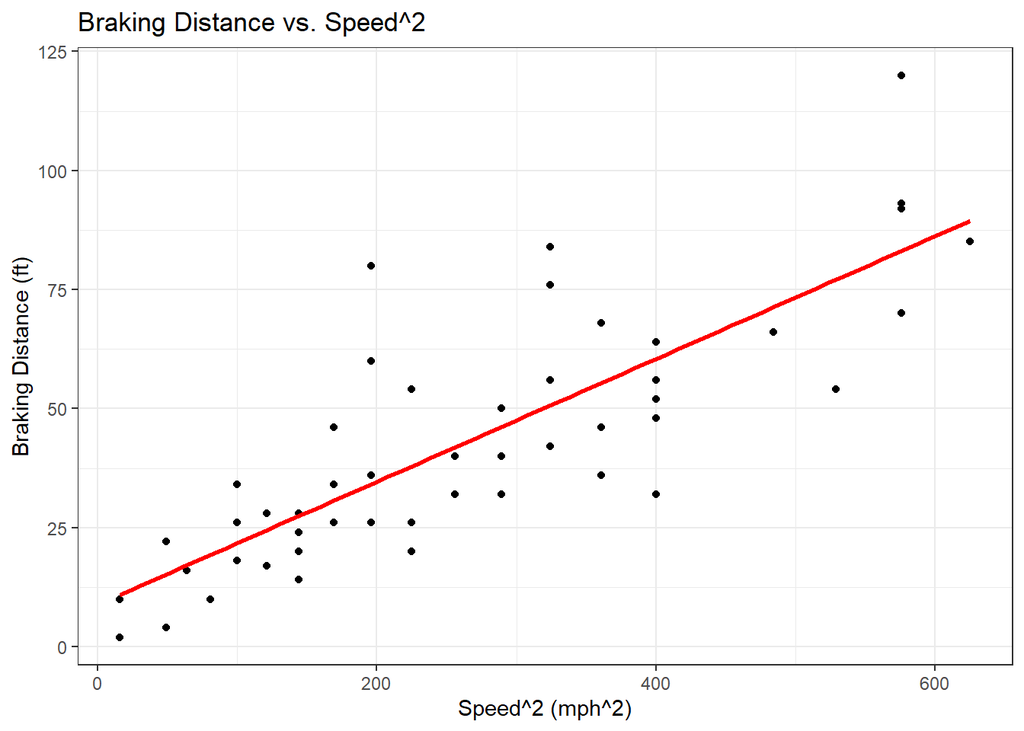

```r
ggplot(cars2, aes(x = speed2, y = dist)) +
  geom_point() +
  geom_smooth(method = "lm", se = FALSE, color = "red") +
  labs(title = "Braking Distance vs. Speed^2",
       x = "Speed^2 (mph^2)",
       y = "Braking Distance (ft)") +
  theme_bw()
```

From here on we only care about the slope, the intercept is ignored as this represents the reaction time value we’re looking for at different speeds.

```r
# Next, calculate the predicted values during braking only

cars2$predicted_stopping_distance=cf[2]*cars2$speed2

# During braking the average speed is half of initial speed
# Need to convert the units: 1 mph = 1.46667 ft/s

cars2$avg_braking_speed_ft_s=1.46667*cars2$speed/2

# Calculate stopping time by dividing distance/speed
# Do this both for predicted and actual stopping time
cars2$predicted_stopping_time=cars2$predicted_stopping_distance/cars2$avg_braking_speed_ft_s
cars2$actual_stopping_time=cars2$dist/cars2$avg_braking_speed_ft_s
```

Now the calculation is a simple mean of the difference in stopping times between the predicted time (which excludes any intercept) and the actual time. This implictly assumes a slope of 1 between the predicted and actual values (as stated in the question), which reduces to the calculation of the mean of the difference.

```r
#
react_time <- mean(cars2$actual_stopping_time-cars2$predicted_stopping_time)

cat("The estimated reaction time is",react_time,"s")
```

```
## The estimated reaction time is 0.8814234 s
```

0.88 seconds is a reasonable estimate of stopping time, which is estimated at around 0.75 seconds in various public sources

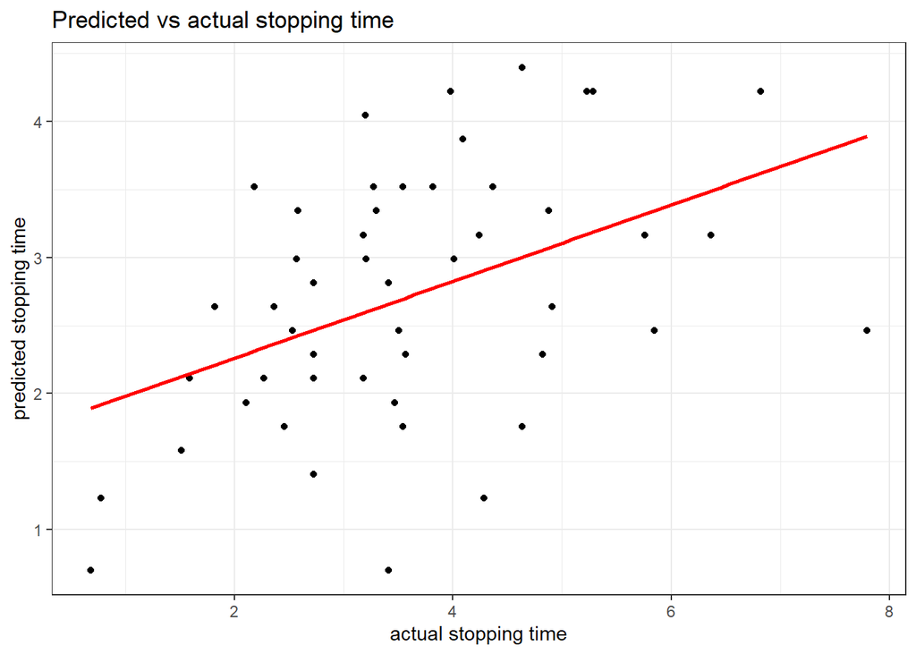

```r
ggplot(cars2, aes(x = actual_stopping_time, y = predicted_stopping_time)) +
  geom_point() +
  geom_smooth(method = "lm", se = FALSE, color = "red") +
  labs(title = "Predicted vs actual stopping time",
       x = "actual stopping time",
       y = "predicted stopping time") +
  theme_bw()
```

The slope in the graph is less than 1, which is probably due to the fact that the square function does not perfectly fit the actual stopping distance. This may be driven by some outliers, such as the near 8 second actual stopping time vs. a predicted 2.5 seconds on the right of the chart (14mph taking 80ft to stop in row 23).

# RNA-seq assessment (8 pts)

## 3.8

```r
all_counts <- read.csv(file = paste0(dirname(path.expand('~')),"/Downloads/LMS/exercises/data/all_counts.csv"), row.names = 1)
sam_des <- read.table(file=paste0(dirname(path.expand('~')),"/Downloads/LMS/exercises/data/sample_description.txt"), sep = "\t", header = TRUE)
```

## 3.9

```r
col_data <- data.frame(Sample = sam_des$Sample,
                  Group = sam_des$Group,
                  Batch = sam_des$Batch)
cat("The dimensions of the col_data dataframe of",dim(col_data)[1],"match the length of the description",dim(sam_des)[1],"while we selected",dim(col_data)[2],"of",dim(sam_des)[2],"columns from sam_des only")
```

```
## The dimensions of the col_data dataframe of 6 match the length of the description 6 while we selected 3 of 6 columns from sam_des only
```

## 3.10

```r
#if (!require("BiocManager", quietly = TRUE))
#    install.packages("BiocManager")
#BiocManager::install("DESeq2")

library(DESeq2)
dds <- DESeqDataSetFromMatrix(countData = all_counts,
                              colData = col_data,
                              design = ~Group)
dds <- DESeq(dds)
```

## 3.11

```r
rld <- rlog(dds)
vsd <- varianceStabilizingTransformation(dds)
```

## 3.12

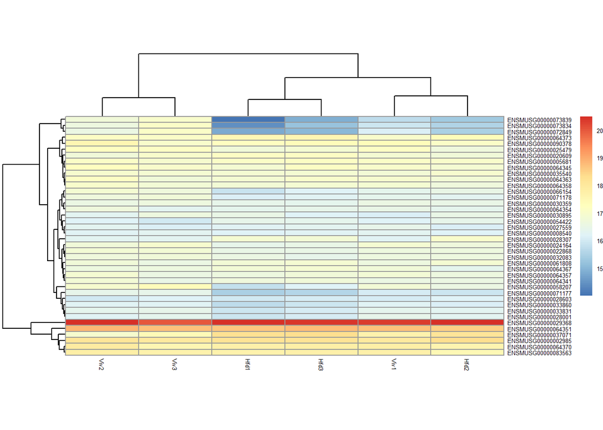

```r
#BiocManager::install("DESeq2")
library("pheatmap")
dds_counts <- counts(dds, normalized = TRUE)
select <- order(rowMeans(dds_counts), decreasing = TRUE)[1:40]
pheatmap(assay(rld)[select, ],cellheight=5,fontsize = 5)
```

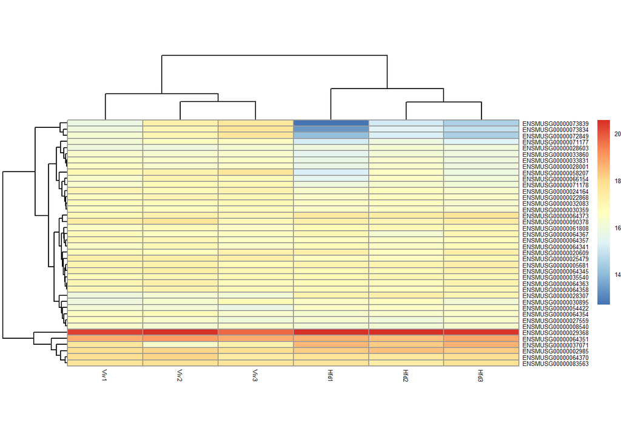

```r
pheatmap(assay(vsd)[select, ],cellheight=5,fontsize = 5)
```

## 3.13

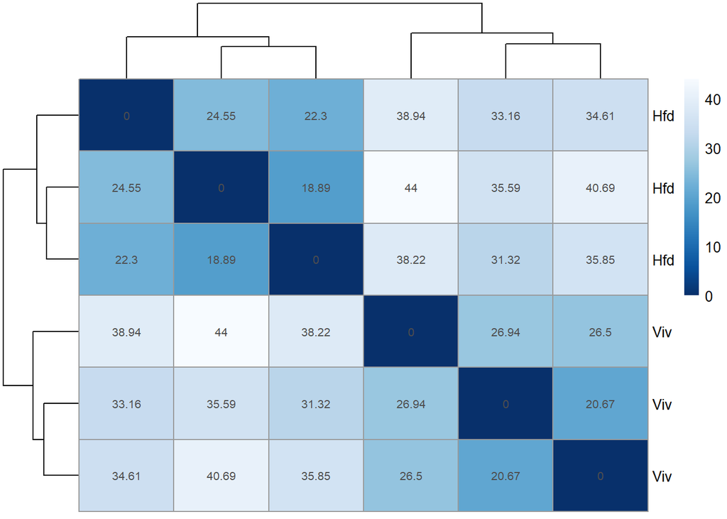

```r
sample_dist <- dist(t(assay(rld)))
sdm <- as.matrix(sample_dist)
library("RColorBrewer")
rownames(sdm) <- rld$Group
colnames(sdm) <- NULL
colors <- colorRampPalette(rev(brewer.pal(9, "Blues")))(255)
pheatmap(sdm,
         clustering_distance_rows = sample_dist,
         clustering_distance_cols = sample_dist,
         col = colors,
         display_numbers = round(sdm,2))
```

## 3.14

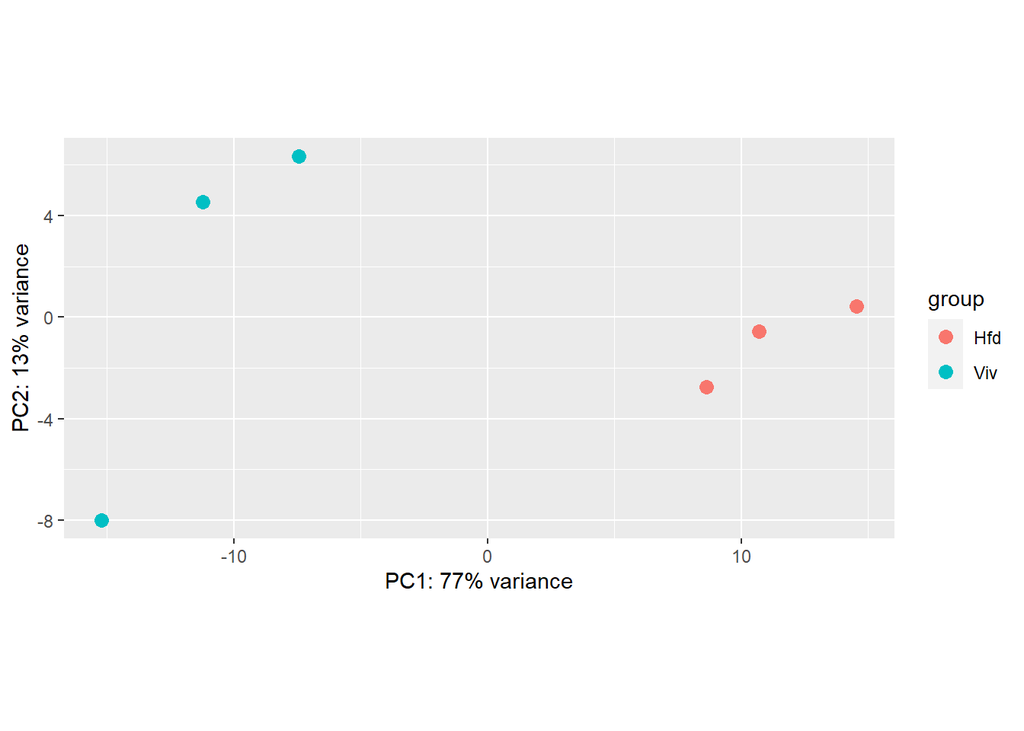

```r
plotPCA(rld, intgroup = "Group")
```

The variance of the first principal component is 77% and 13% for the second principal component.

## 3.15

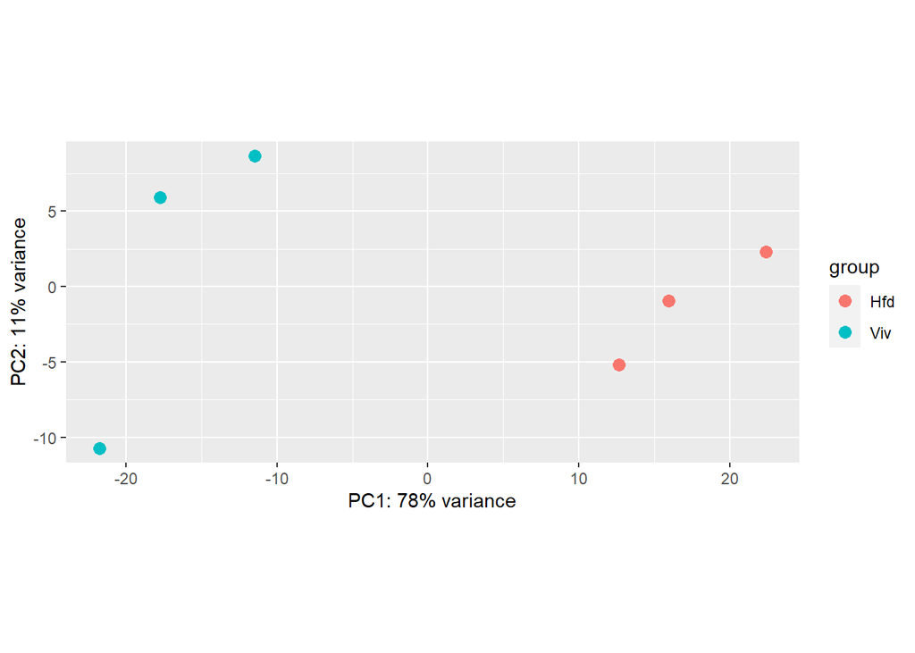

```r
plotPCA(vsd, intgroup = "Group")
```

The variance of the first principal component is 78% and 11% for the second principal component.

The results and plots between the rlog method and VST method are quite similar, the VST method assigns slightly more variance to the first PC and less to the second one.

# ChIP-seq assessment (4 pts)

## 3.16

```r
library('ChIPQC')
firstPeakSet <- ChIPQC:::GetGRanges(paste0(dirname(path.expand('~')),"/Downloads/LMS_ChIPseq_short-master-2023-final/course/data/MacsPeaks/mycmelrep1_peaks.xls"), sep="\t", simple=F)
secondPeakSet <- ChIPQC:::GetGRanges(paste0(dirname(path.expand('~')),"/Downloads/LMS_ChIPseq_short-master-2023-final/course/data/MacsPeaks/mycmelrep2_peaks.xls"), sep="\t", simple=F)
firstANDsecondPeakSets <- firstPeakSet[firstPeakSet %over% secondPeakSet]
length(firstANDsecondPeakSets)
```

```
## [1] 30233
```

## 3.17

```r
foldEnrichment <- firstANDsecondPeakSets$fold_enrichment
sorted_gr <- firstANDsecondPeakSets[order(foldEnrichment, decreasing=TRUE)]
sorted_resized_gr <- resize(sorted_gr[1:500],width=200,fix="center")
```

## 3.18

```r
library(TxDb.Mmusculus.UCSC.mm9.knownGene)
library(org.Mm.eg.db)
library(GenomeInfoDb)
library(ChIPseeker)
library(BSgenome.Mmusculus.UCSC.mm9)
#BiocManager::install("BSgenome.Mmusculus.UCSC.mm9")

seqlevelsStyle(sorted_resized_gr) <- 'UCSC'
sorted_resized_gr[1:2,]
```

```
## GRanges object with 2 ranges and 7 metadata columns:
##       seqnames            ranges strand |        ID     Score      Strand
##          <Rle>         <IRanges>  <Rle> | <integer> <integer> <character>
##   [1]     chr4 45966312-45966511      * |      1430  45966486           *
##   [2]     chr9 21156572-21156771      * |      2848  21157016           *
##       X.log10.pvalue. fold_enrichment X.log10.qvalue.                  name
##             <numeric>       <numeric>       <numeric>           <character>
##   [1]         488.149         123.116         479.841 mycmelrep1_peak_33018
##   [2]         437.832         111.535         430.369 mycmelrep1_peak_48303
##   -------
##   seqinfo: 22 sequences from an unspecified genome; no seqlengths
```

```r
peakAnno <- annotatePeak(sorted_resized_gr, tssRegion = c(-1000, 1000), TxDb = TxDb.Mmusculus.UCSC.mm9.knownGene,
    annoDb = "org.Mm.eg.db")
```

```
## >> preparing features information...      2023-04-19 8:49:42 PM
## >> identifying nearest features...        2023-04-19 8:49:43 PM
## >> calculating distance from peak to TSS...   2023-04-19 8:49:43 PM
## >> assigning genomic annotation...        2023-04-19 8:49:43 PM
## >> adding gene annotation...          2023-04-19 8:49:50 PM
## >> assigning chromosome lengths           2023-04-19 8:49:50 PM
## >> done...                    2023-04-19 8:49:50 PM
```

```r
peakAnno_GR <- as.GRanges(peakAnno)
seq <- getSeq(BSgenome.Mmusculus.UCSC.mm9,peakAnno_GR)
seq_info <- paste(peakAnno_GR$transcriptId,peakAnno_GR$ENSEMBL,peakAnno_GR$ID,sep='_')
names(seq) <- seq_info
writeXStringSet(seq,file=paste0(dirname(path.expand('~')),"/Downloads/LMS_ChIPseq_short-master-2023-final/course/mycmelrep_peaks.fasta"))
```